# act_report

## WeRateDogs Twitter Archive - Act Report

- Create a **250-word-minimum written report** called "act_report.pdf" or "act_report.html" that communicates the insights and displays the visualization(s) produced from your wrangled data. This is to be framed as an external document, like a blog post or magazine article, for example.

#### About the data

To analyze WeRateDogs™ tweets, we used three different sources. The first source is an archive of past tweets from @dog_rates (https://twitter.com/dog_rates) provided via a CSV file from Udacity. The second source is from the Twitter API, which is used to retrieve more information about the tweets, such as the number of individual tweets that have been retweeted. The third data source provides us with the predicted dog breed in the image of each tweet, which is programmatically determined by a neural network. This was also provided by Udacity. This third source is particularly important because it did not determine how accurate the predictions were. Combining the data from these sources, we were eventually able to analyze 2174 tweets from WeRateDogs™. These Tweets were from before August 2017 and were used to determine the relationship between retweets and favorits between the different "dog levels" (Floofer, Pupper, Doggo, etc.), the distribution of Ratings and the popularity of dog breeds .

#### Data Wrangling

The goal for me was to process the Twitter data from WeRateDogs to provide interesting and reliable analytics and visualizations. The Twitter archive is a good start, but it only contains very basic information about tweets. Therefore, additional data had to be collected, analyzed and cleaned to create worthy analyses and visualizations. I extracted from the Twitter API the number of retweets and the number of favorites, two of the most important missing columns. I also used the Requests library to programmatically download an image prediction file that can classify dog breeds. After cleaning up many of the issues found during the evaluation, there were about a good 2000 tweets with good quality data that could finally be examined and analyzed

#### Insights

##### 1-Favorites and retweets analysis

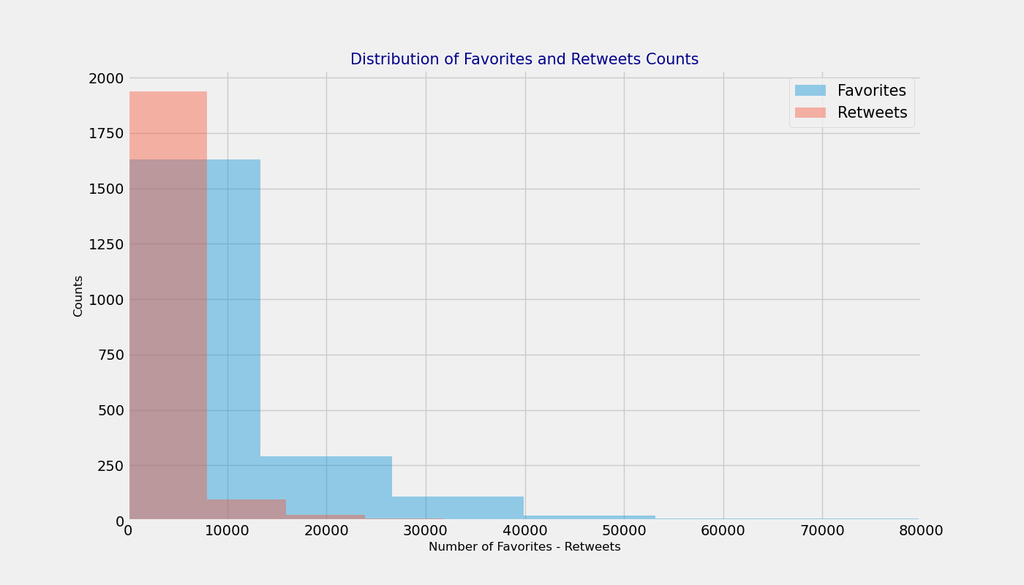

```python
from IPython.display import Image
Image(filename='img\Favs_retweets_counts.png')
```

The distribution of the number of favorites and retweets follows the same pattern.

##### 2-most common dog breeds

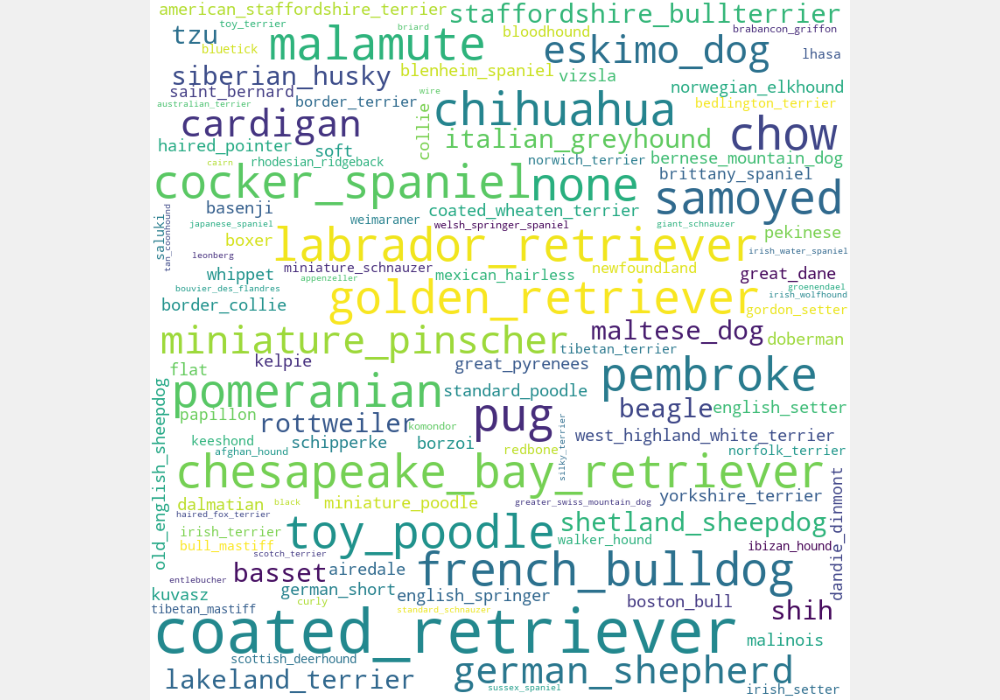

```python
Image(filename='img\most_common_dog_breeds.png')
```

##### 3-Distribution of Ratings

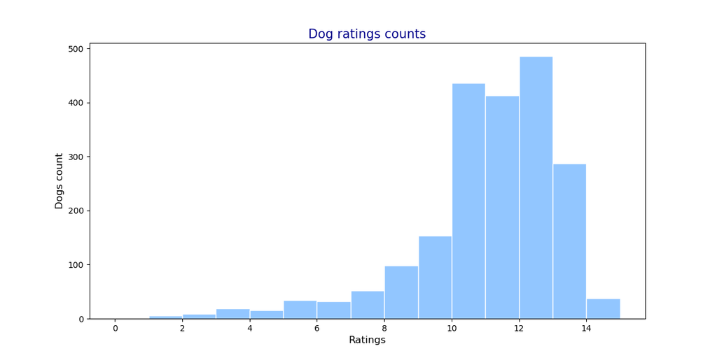

```python
Image(filename='img\Dogs_ratings_counts.png')
```

##### 4-Top ranked dog(s)

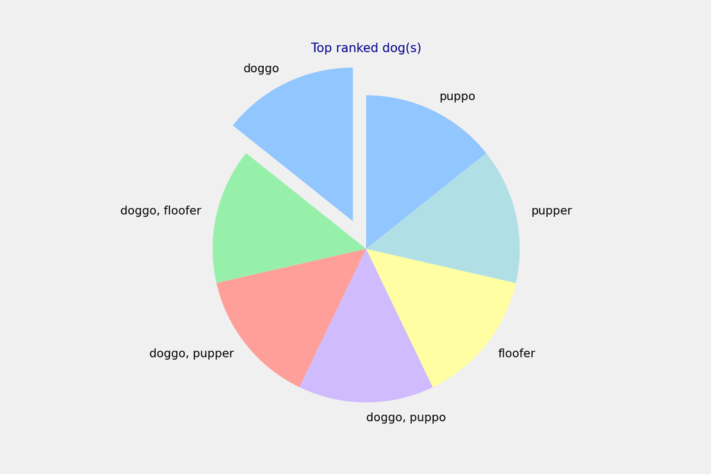

```python
Image(filename='img\Top_ranked_Dog.png')
```